# Climatic niche differences betwqeen colour morphs

#### Niche similarity test

**Under niche conservatism** Niche equivalency test H0: niche overlap is similar to the random distribution

Niche equivalency test H1: the observed overlap between A and B niche is higher than if the two niches are randomized

**Under niche divergence** Niche divergence test H0: niche overlap is similar to the random distribution

Niche divergence test H1: the observed overlap between A and B niche is lower than if the two niches are randomized

```r
sim_test_1_cons <- ecospat.niche.similarity.test(orange_grid,
                                          nonmelanic_grid,
                                          rep=1000,
                                          overlap.alternative = "higher",
                                          rand.type=1)
sim_test_2_cons <- ecospat.niche.similarity.test(nonmelanic_grid,
                                            orange_grid,
                                          rep=1000,
                                          overlap.alternative = "higher",
                                          rand.type=1)
```

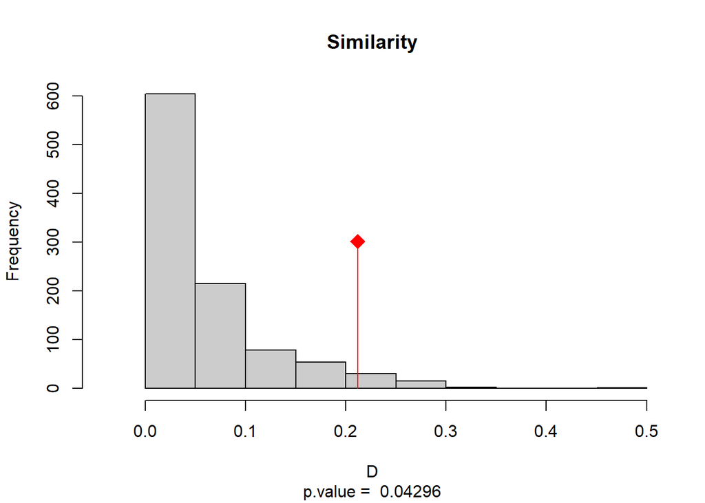

```r
ecospat.plot.overlap.test(sim_test_1_cons, "D", "Similarity")
```

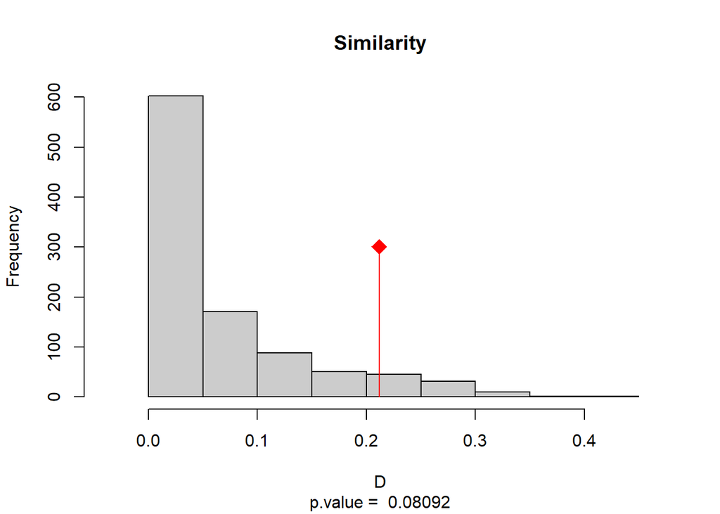

```r
ecospat.plot.overlap.test(sim_test_2_cons, "D", "Similarity")
```

```r
sim_test_1_div <- ecospat.niche.similarity.test(orange_grid,
                                          nonmelanic_grid,
                                          rep=1000,
                                          overlap.alternative = "lower",
                                          rand.type=1)
sim_test_2_div <- ecospat.niche.similarity.test(nonmelanic_grid,
                                            orange_grid,
                                          rep=1000,
                                          overlap.alternative = "lower",
                                          rand.type=1)
```

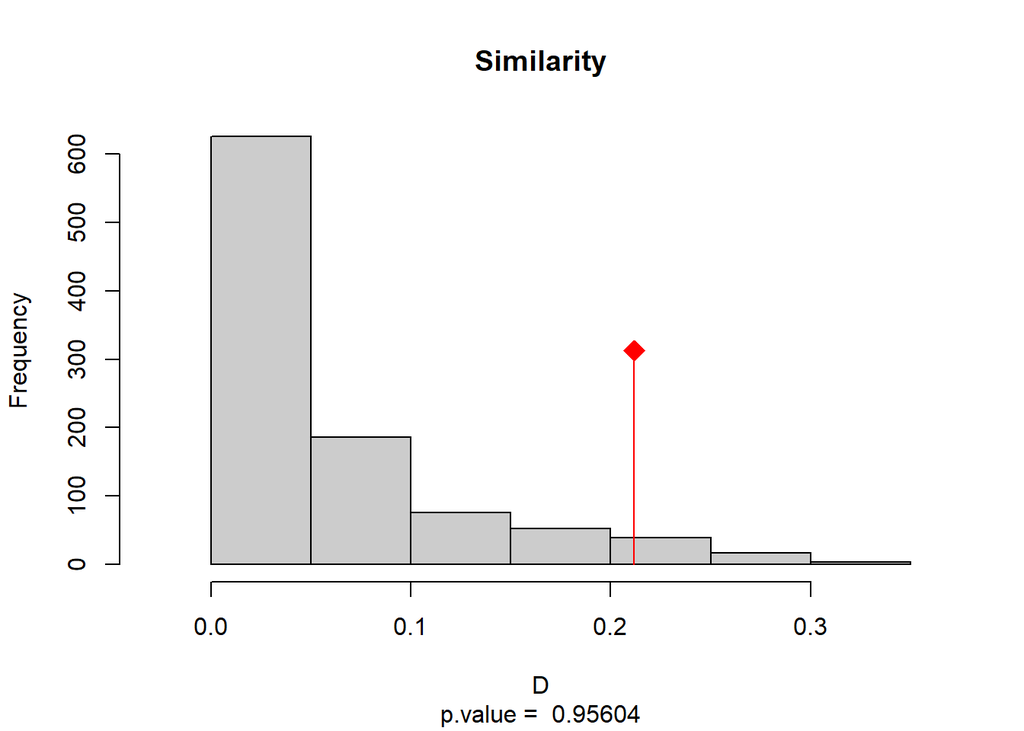

```r
ecospat.plot.overlap.test(sim_test_1_div, "D", "Similarity")
```

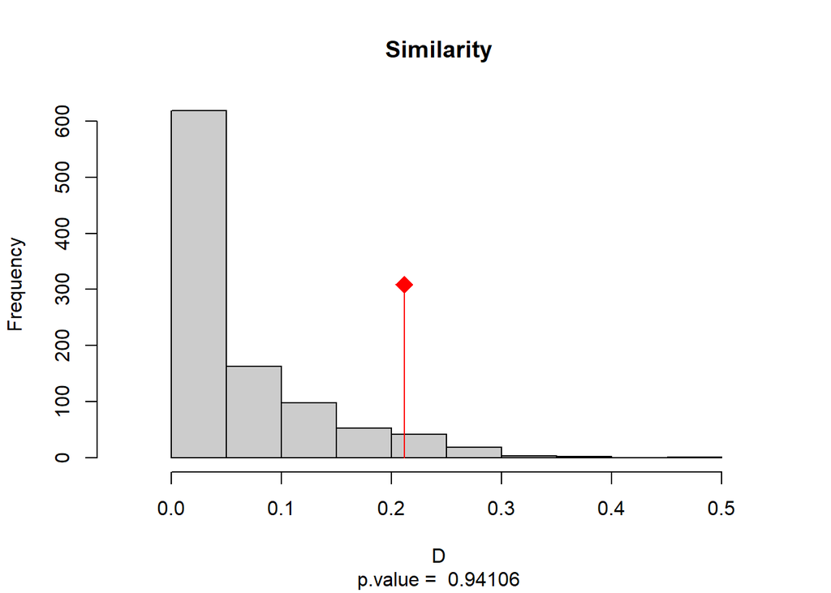

```r
ecospat.plot.overlap.test(sim_test_2_div, "D", "Similarity")
```